# FP_02_beta_diversity - Outliers removed - Only Batch 2 without RI

Kris de Kreek

2026-05-21

# 2.0 - Basic beta diversity analysis

This script should be run after script “01_loading_and_pre_processing.rmd” because it generates all the global environment objects and also loads the libraries

On this script we will evaluate beta diversity - the differences in the microbial community compositions across samples. We will make ordination plots and multivariate tests

This script is originally made by Pedro Beschoren da Costa for the MeJA_Pilot and modified to fit my data.

### Load libraries

```r
library(purrr)
packageVersion("purrr")
```

```
## [1] '1.1.0'
```

```r
library(phyloseq)
packageVersion("phyloseq")
```

```
## [1] '1.52.0'
```

```r
library(ggplot2)
packageVersion("ggplot2")
```

```
## [1] '4.0.0'
```

```r
library(vegan)
packageVersion("vegan")
```

```
## [1] '2.7.2'
```

```r
library(tibble) #needed for function rownames_to_columns
packageVersion("tibble")
```

```
## [1] '3.3.0'
```

```r
library(factoextra) #for heatmap function fviz_dist
packageVersion("factoextra")
```

```
## [1] '1.0.7'
```

```r
library(patchwork) # for wrap_plot
packageVersion("patchwork")
```

```
## [1] '1.3.2'
```

```r
library(cowplot) # for extracting legend
packageVersion("cowplot")
```

```
## [1] '1.2.0'
```

```r
library(ggh4x) #for coloring strip facet wrap
packageVersion("ggh4x")
```

```
## [1] '0.3.1'
```

# 2.1 - Beta Diversity plots

Beta diversity plots are the beating heart or microbiome analysis. Here you will be able to visually tell if communities differ according to treatment or not. It can be a very long topic but here I only use one option.

## 2.1.1 - Loading data

```r
load("C:/Users/kreek001/OneDrive - Wageningen University & Research/Chapters/Experimental Chapter 3/RScripts/GitHub/Data/R_objects/FP_CSS_bac_ps.RData")
```

### Remove outliers

```r
Outliers <- c("F178")
samples_to_keep <- setdiff(sample_names(FP_CSS_bac_ps), Outliers) # only keep samples that are not in both objects
FP_CSS_bac_ps <- prune_samples(samples_to_keep, FP_CSS_bac_ps) #only keep samples that are in samples_to_keep
```

### Remove batch 1 and RI

```r
FP_CSS_bac_ps <- subset_samples(FP_CSS_bac_ps, Batch != 1)
FP_CSS_bac_ps <- subset_samples(FP_CSS_bac_ps, Accession != "RI")
levels(sample_data(FP_CSS_bac_ps)$Accession)
```

```
## [1] "VL"  "CD"  "HM"  "GO1"
```

### Remove unplanted CTRL

Unplanted CTRL samples appears to from the CP.

```r
FP_CSS_bac_ps <- subset_samples(FP_CSS_bac_ps, Accession != "Un")
```

### Remove Co cat treatment

```r
FP_CSS_bac_ps <- subset_samples(FP_CSS_bac_ps, Cat_treatment != "Co")
```

### Phyloseq object per accession

```r
Acc <- c("VL", "CD", "HM", "GO1")
filtered_ps <- list()

filtered_ps <- lapply(Acc, function(x) {
  samples_to_keep <- sample_names(FP_CSS_bac_ps)[sample_data(FP_CSS_bac_ps)$Accession == x]
  prune_samples(samples_to_keep, FP_CSS_bac_ps)
})
names(filtered_ps) <- Acc  # Name each list element with the corresponding accession
```

## 2.1.3 PCoA plots at ASV level

### PCoA plot without unplanted CTRL

```r
# Calculate Bray-Curtis distance matrix
bray_dist <- distance(FP_CSS_bac_ps, method = "bray")

# Run classical MDS with cmdscale()
mds_result <- cmdscale(bray_dist, k = 2, eig = TRUE)

# Extract coordinates
mds_coords <- as.data.frame(mds_result$points)
colnames(mds_coords) <- c("MDS1", "MDS2")

# Add sample IDs as a column
mds_coords$SampleID <- rownames(mds_coords)

# Extract sample metadata
metadata_df <- data.frame(sample_data(FP_CSS_bac_ps))
metadata_df$SampleID <- rownames(metadata_df)

# Merge ordination coordinates with metadata
plot_df <- merge(mds_coords, metadata_df, by = "SampleID")

# Eigenvalues percentage explained variance
perc_expl1 <- 100 * (mds_result$eig / sum(mds_result$eig))
perc_expl1[1:4] # percentage explained first four axes
```

```
## [1] 8.712538 5.257216 4.758322 3.795875
```

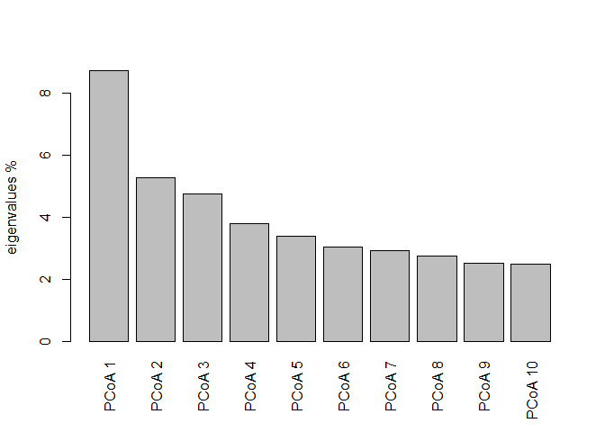

```r
barplot(perc_expl1[1:10], names = paste ('PCoA', 1:10), las = 3, ylab = 'eigenvalues %')
```

#### Accessions colored

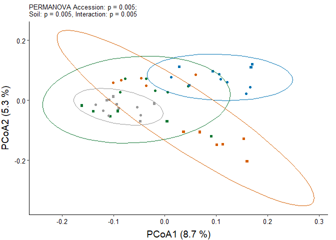

```r
colors4 <- c("#0072B2", "#117733", "#D55E00", "#999999") #"#009E73", "#CC79A7", "#E69F00", "#000000", "#F0E442", "#56B4E9", "#117733"

p <- ggplot(plot_df, aes(x = MDS1, y = MDS2, color = Accession, shape = Soil_conditioning)) +
  geom_point(size = 1.5, alpha = 1) +
  stat_ellipse(aes(group = Accession),
               show.legend = FALSE) +
  scale_color_manual(values = colors4) +
  scale_shape_manual(name = "Soil treatment",
                     values = c(Co = 16, Mb = 15),
                     labels = c(Co = "Control", Mb = expression(italic("M. brassicae")))) +
  xlab(paste0("PCoA1 (", round(perc_expl1[1], 1), " %)")) +
  ylab(paste0("PCoA2 (", round(perc_expl1[2], 1), " %)")) +
  ggtitle("PERMANOVA Accession: p = 0.005;\nSoil: p = 0.005, Interaction: p = 0.005") +
  theme(panel.background = element_rect(fill = "white"), #theme of the graph
        panel.border = element_blank(),
        axis.line = element_line(), #show line for x and y axis
        plot.title = element_text(size = 10, hjust = 0),
        axis.text = element_text(size = 10, color = "black"),
        axis.title = element_text(size = 14),
        axis.title.x = element_text(vjust = -0.5),
        axis.title.y = element_text(vjust = 2.5), #, hjust = -0
        legend.title = element_text(size = 14),
        legend.text = element_text(size = 12),
        #strip.text = element_text(size = 13),
        plot.margin = margin(5.5, 12, 5.5, 5.5, "points"),
        legend.position = "none")
print(p)
```

```r
mapply(function(x)
  ggsave(plot = last_plot(),
         filename = x,
         path = "C:/Users/kreek001/OneDrive - Wageningen University & Research/Chapters/Experimental Chapter 3/Result/Final graphs",
         scale = 2.2,
         width = 4.3,
         height = 4.45,
         units = "cm",
         dpi = 300),
  x = c("FP_BetaDiv_Acc_Soil.svg", "FP_BetaDiv_Acc_Soil.png"))
```

```
##                                                                                                                     FP_BetaDiv_Acc_Soil.svg
## "C:/Users/kreek001/OneDrive - Wageningen University & Research/Chapters/Experimental Chapter 3/Result/Final graphs/FP_BetaDiv_Acc_Soil.svg"
##                                                                                                                     FP_BetaDiv_Acc_Soil.png
## "C:/Users/kreek001/OneDrive - Wageningen University & Research/Chapters/Experimental Chapter 3/Result/Final graphs/FP_BetaDiv_Acc_Soil.png"
```

```r
# Legend
legend_acc <- get_legend(p + theme(legend.position = "right"))
```

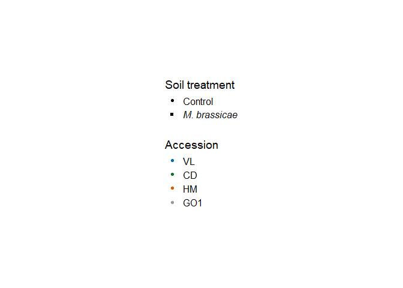

```r
ggdraw(legend_acc)
```

```r
mapply(function(x)
  ggsave(plot = last_plot(),
         filename = x,
         path = "C:/Users/kreek001/OneDrive - Wageningen University & Research/Chapters/Experimental Chapter 3/Result/Final graphs",
         scale = 2.2,
         width = 1.8,
         height = 2.9,
         units = "cm",
         dpi = 300),
  x = c("FP_BetaDiv_Acc_Soil_legend.svg", "FP_BetaDiv_Acc_Soil_legend.png"))
```

```
##                                                                                                                     FP_BetaDiv_Acc_Soil_legend.svg
## "C:/Users/kreek001/OneDrive - Wageningen University & Research/Chapters/Experimental Chapter 3/Result/Final graphs/FP_BetaDiv_Acc_Soil_legend.svg"
##                                                                                                                     FP_BetaDiv_Acc_Soil_legend.png
## "C:/Users/kreek001/OneDrive - Wageningen University & Research/Chapters/Experimental Chapter 3/Result/Final graphs/FP_BetaDiv_Acc_Soil_legend.png"
```

#### Accession colored without elipse

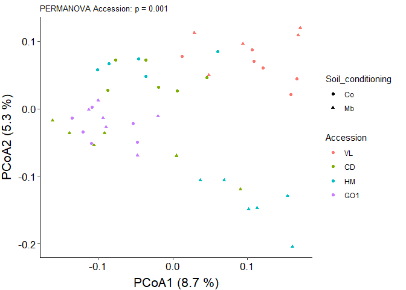

```r
ggplot(plot_df, aes(x = MDS1, y = MDS2, color = Accession, shape = Soil_conditioning)) +
  geom_point(size = 1.5, alpha = 1) +
  xlab(paste0("PCoA1 (", round(perc_expl1[1], 1), " %)")) +
  ylab(paste0("PCoA2 (", round(perc_expl1[2], 1), " %)")) +
  ggtitle("PERMANOVA Accession: p = 0.001") +
  theme(panel.background = element_rect(fill = "white"), #theme of the graph
        panel.border = element_blank(),
        axis.line = element_line(), #show line for x and y axis
        plot.title = element_text(size = 10, hjust = 0),
        axis.text = element_text(size = 13, color = "black"),
        axis.title = element_text(size = 16),
        axis.title.x = element_text(vjust = -0.5),
        axis.title.y = element_text(vjust = 2.5), #, hjust = -0
        strip.text = element_text(size = 13),
        plot.margin = margin(5.5, 12, 5.5, 5.5, "points"),
        legend.position = "right")
```

#### Accession colored with elipse

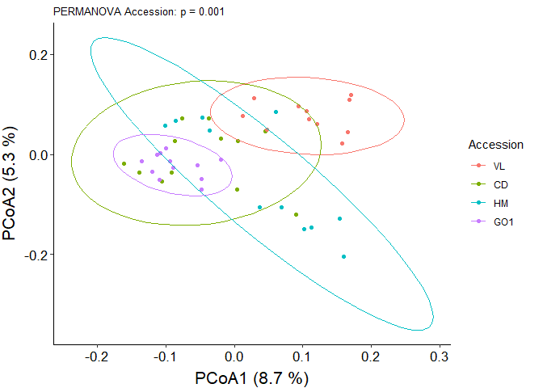

```r
ggplot(plot_df, aes(x = MDS1, y = MDS2, color = Accession)) +
  geom_point(size = 1.5, alpha = 1) +
  stat_ellipse() +
  xlab(paste0("PCoA1 (", round(perc_expl1[1], 1), " %)")) +
  ylab(paste0("PCoA2 (", round(perc_expl1[2], 1), " %)")) +
  ggtitle("PERMANOVA Accession: p = 0.001") +
  theme(panel.background = element_rect(fill = "white"), #theme of the graph
        panel.border = element_blank(),
        axis.line = element_line(), #show line for x and y axis
        plot.title = element_text(size = 10, hjust = 0),
        axis.text = element_text(size = 13, color = "black"),
        axis.title = element_text(size = 16),
        axis.title.x = element_text(vjust = -0.5),
        axis.title.y = element_text(vjust = 2.5), #, hjust = -0
        strip.text = element_text(size = 13),
        plot.margin = margin(5.5, 12, 5.5, 5.5, "points"),
        legend.position = "right")
```